# Hechos estilizados

Rolando Fortanell

2025-02-04

Los hechos estilizados son eventos que suceden de manera repetitiva y entonces asumimos que ese evento volvera a suceder

Los hechos estilizados referentes al comportamiento del precio y del rendimiento de un activo que cotiza en una volsa de valores, son los sisguientes:

## Hecho estilizado 1:

Los precios de los activos y el valor de los portafolio siguen una caminata aleatoria.

Para verificar este hecho primero vamos a graficar una caminata aleatoria.

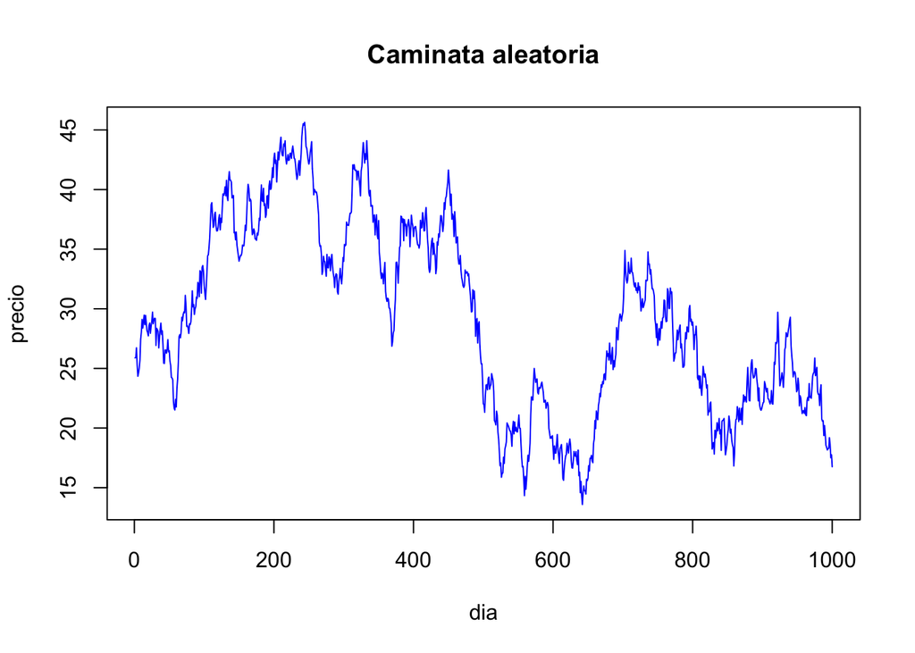

```r
n <- 1000
So <- 25
epsilon <- rnorm(n)
St <- So+cumsum(epsilon)
plot(St, type="l", xlab="dia", ylab="precio", col="blue", main="Caminata aleatoria")
```

Vamos a comparar este comportamiento con el del precio de un activo

```r
library(quantmod)
datos <- new.env()
clave <- "GFNORTEO.MX"
getSymbols(clave, env=datos)
```

```
## [1] "GFNORTEO.MX"
```

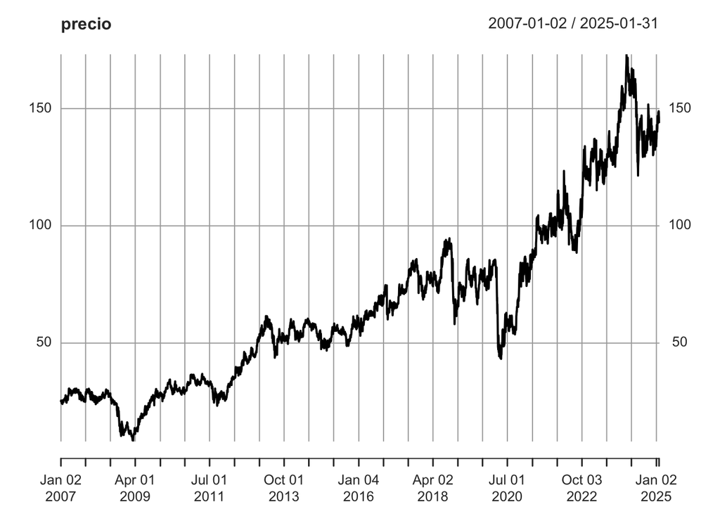

```r
precio <- datos[[clave]][,6]

plot(precio)
```

## Hecho estilizado 2:

La distribución del rendimiento del precio tiene una forma aproximadamente “acampanada”.

Una caracteristica del comportamiento del rendimiento es que cuando hacemos su histograma para ver su distribución se observa una especie de campana con ciertas deformaciones. Nota, recuerda que el comportamiento de campana hace referencia a la distribucion normal.

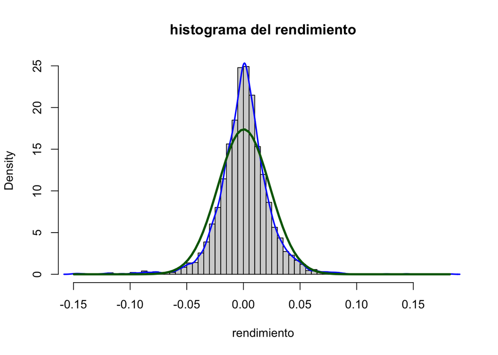

```r
rendimiento <- na.omit(diff(log(precio)))
hist(rendimiento, n = 100,main="histograma del rendimiento", prob = TRUE)
lines(density(rendimiento), col="blue", lwd=2)
xval <- seq(min(rendimiento),max(rendimiento), length.out=100)
lines(xval, dnorm(xval, mean=mean(rendimiento),sd=sd(rendimiento)), col="darkgreen",lwd=3)
```

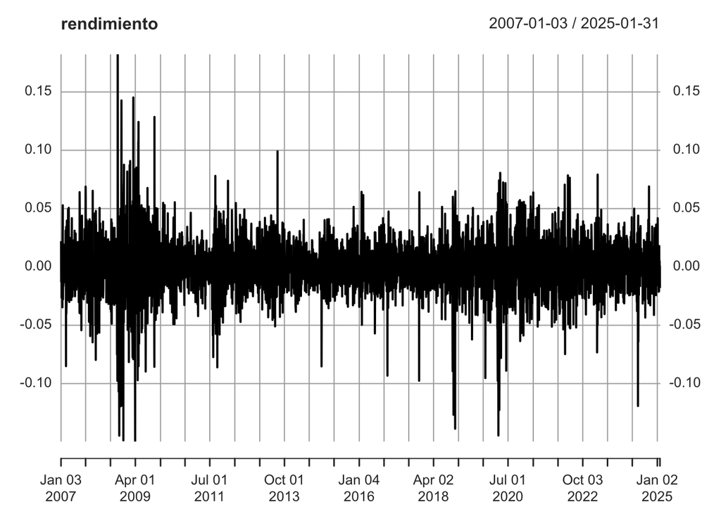

```r
plot(rendimiento)
```

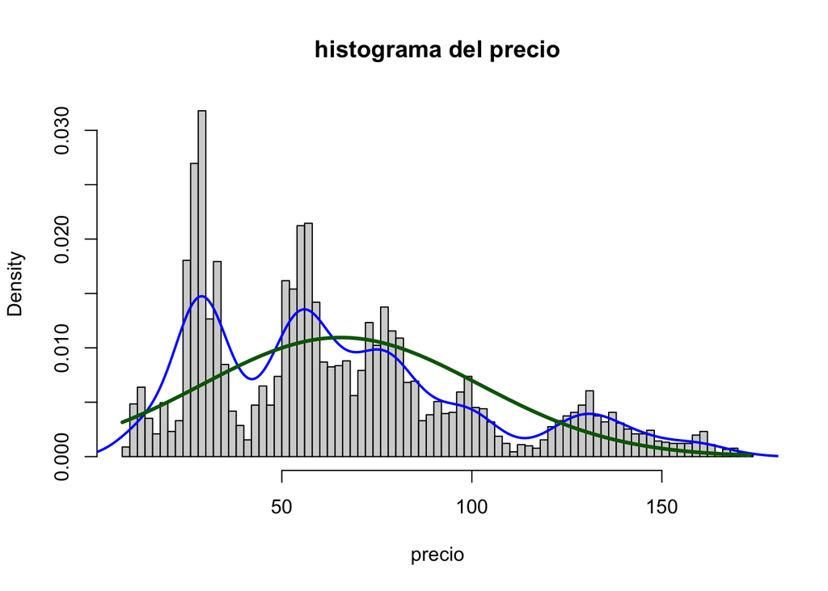

```r
hist(precio, n = 100,main="histograma del precio", prob = TRUE)
lines(density(precio), col="blue", lwd=2)
xval <- seq(min(precio),max(precio), length.out=100)
lines(xval, dnorm(xval, mean=mean(precio),sd=sd(precio)), col="darkgreen",lwd=3)
```

## Hecho estilizado 3:

Los rendimientos de los activos presentan volatilidad no constante y agrupada

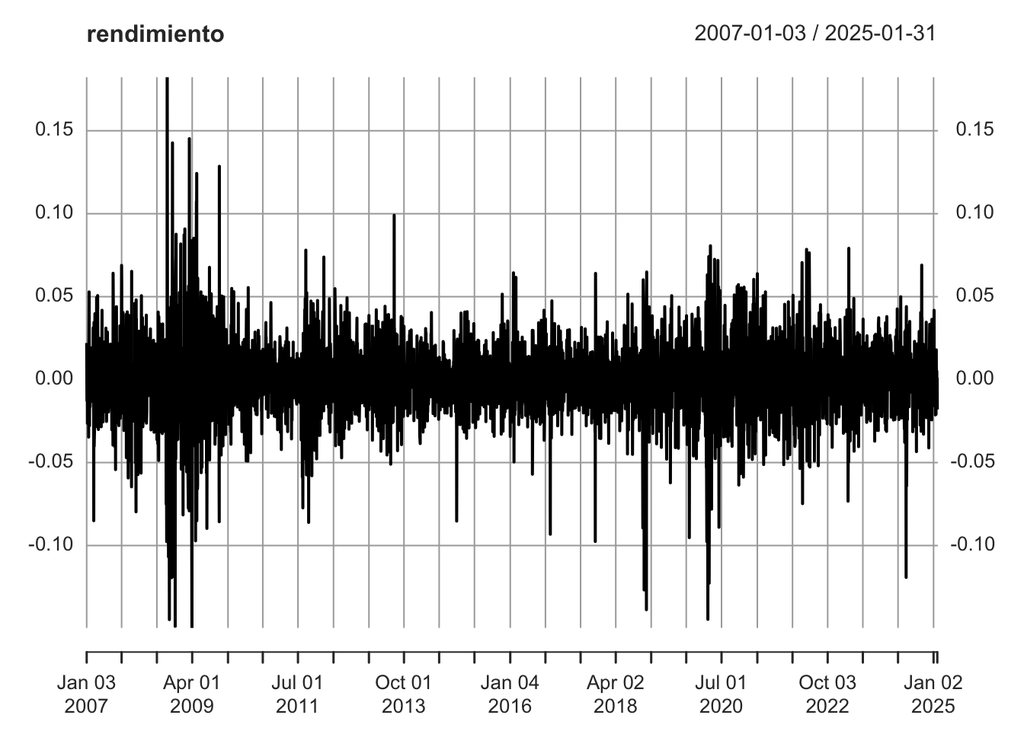

```r
plot(rendimiento)
```

```r
to.monthly(precio)
```

```
##          precio.Open precio.High precio.Low precio.Close
## Jan 2007    24.85766    25.66932   24.02849     25.55838
## Feb 2007    25.52335    27.74226   24.93942     25.46495
## Mar 2007    26.35835    30.53925   24.57738     30.53925
## Apr 2007    30.65019    30.65019   27.63130     27.77145
## May 2007    28.95682    30.31736   28.51888     29.26047
## Jun 2007    30.18305    30.60932   28.74660     28.95097
## Jul 2007    29.17287    30.06043   26.11311     28.98601
## Aug 2007    28.21523    28.71740   25.57005     26.27077
## Sep 2007    26.84885    27.14665   24.91605     25.06204
## Oct 2007    26.84885    30.27193   26.84885     28.97523
##      ...
## Apr 2024   160.80775   167.11449  154.73903    155.53537
## May 2024   158.62009   162.60184  143.16907    147.52611
## Jun 2024   130.94922   142.18965  121.42047    138.78156
## Jul 2024   143.73317   147.07648  136.37398    136.37398
## Aug 2024   136.19852   140.30212  129.36569    133.09889
## Sep 2024   134.75594   141.18913  131.13969    136.59816
## Oct 2024   146.35516   151.77466  134.49275    136.12054
## Nov 2024   138.36241   145.71185  130.12598    130.42815
## Dec 2024   134.07362   140.27289  132.46001    134.36000
## Jan 2025   136.80000   148.91000  136.80000    143.84000
```

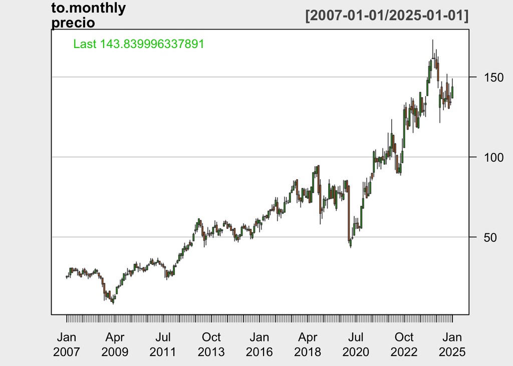

```r
chartSeries(to.monthly(precio), theme="white")
```

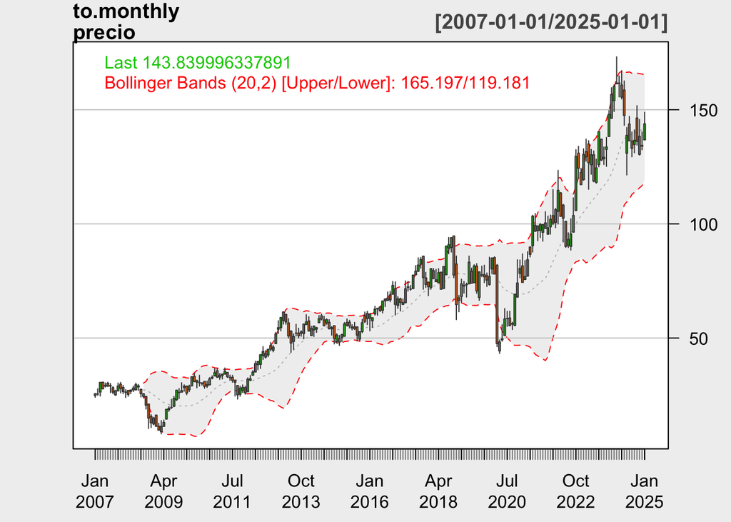

```r
addBBands()
```

En un mercado volatil las bandas de Bollinger se expanden, mientras que en un mercado menos volatil las bandas se estrechan. Esto nos dice que la volitalidad NO ES CONSTANTE y tiende a agruparse.

## Hecho estilizado 4

La distribución de los rendimientos presenta leptocurtosis.

Este hecho nos dice que los rendmientos tienen un exceso de datos alrededor de la media (en exceso comparado con la distribución normal)

Ademas los rendimientos tiene colas pesadas

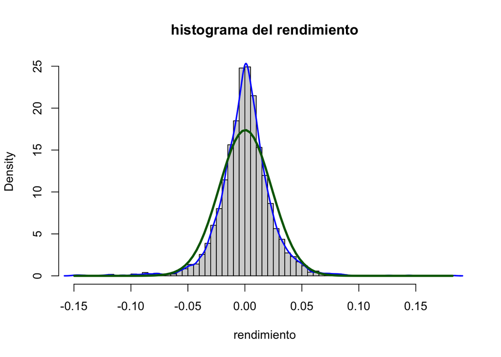

```r
rendimiento <- na.omit(diff(log(precio)))
hist(rendimiento, n = 100,main="histograma del rendimiento", prob = TRUE)
lines(density(rendimiento), col="blue", lwd=2)
xval <- seq(min(rendimiento),max(rendimiento), length.out=100)
lines(xval, dnorm(xval, mean=mean(rendimiento),sd=sd(rendimiento)), col="darkgreen",lwd=3)
```

```r
min(rendimiento)
```

```
## [1] -0.1496356
```

```r
max(rendimiento)
```

```
## [1] 0.1822693
```

```r
mean(rendimiento)
```

```
## [1] 0.0003864265
```